# Acoustic telemetry exploratory analysis

Actel R package (1.2.1)

### Summary

Target folder: E:/Palau/Research/Coastal Fisheries/Natalie Tagging/2022 Bohar tagging/Bohar_2022_2023/Data/Bohar_test

Timestamp: **2023-05-02 09:33:30**

Number of target tags: **66**

Number of listed receivers: **25** (of which **17** had no detections)

Data time range: 2022-11-04 05:23:00 to 2022-11-26 03:56:00 (Pacific/Guam).

Percentage of post-release valid detections: 100%

Found a bug? [**Report it here.**](https://github.com/hugomflavio/actel/issues)

Want to cite actel in a publication? Run `citation('actel')`

### Study area

Release sites are marked with “R.S.”. Arrays connected with an arrow indicate that the tags can only pass in one direction.

[figure not shown]

### Receiver stations

| Station.name | Latitude | Longitude | Array | Standard.name |
| --- | --- | --- | --- | --- |
| Rebotel | 7.250410 | 134.2398 | Rebotel | St.1 |
| Movement corridor 1 | 7.251840 | 134.2231 | Movement_North | St.2 |
| Movement corridor 3 | 7.273140 | 134.1950 | Movement_North | St.3 |
| Mutiaur 1 | 7.276160 | 134.1868 | Mutiaur | St.4 |
| Mutiaur 4 | 7.274850 | 134.1856 | Mutiaur | St.5 |
| Mutiaur 3 | 7.273700 | 134.1850 | Mutiaur | St.6 |
| Mutiaur 2 | 7.275290 | 134.1873 | Mutiaur | St.7 |
| Muriaur 5 | 7.274000 | 134.1871 | Mutiaur | St.8 |
| Mutiaur 6 | 7.274740 | 134.1895 | Mutiaur | St.9 |
| Movement corridor 2 | 7.260720 | 134.2107 | Movement_North | St.10 |
| Ulong channel | 7.283020 | 134.2452 | Ulong__channel | St.11 |
| Siaes corner | 7.314200 | 134.2208 | Siaes_corner | St.12 |
| Movement corridor 4 | 7.265020 | 134.1820 | Movement_South | St.13 |
| Movement corridor 5 | 7.253850 | 134.1893 | Movement_South | St.14 |
| Movement corridor 6 | 7.239040 | 134.1981 | Movement_South | St.15 |
| Movement corridor 7 | 7.224620 | 134.2059 | Movement_South | St.16 |
| Movement corridor 8 | 7.190960 | 134.2138 | Movement_South | St.17 |
| Movement corridor A | 7.164660 | 134.2232 | Movement_South | St.18 |
| Blue corner | 7.133750 | 134.2213 | Blue_corner | St.19 |
| Movement corridor B | 7.271060 | 134.2452 | Ulong_sandbar | St.20 |
| Back reef 1 | 7.234690 | 134.2204 | Back_reef | St.21 |
| Back reef 3 | 7.275998 | 134.2589 | Back_reef | St.22 |
| Back reef 4 | 7.293004 | 134.2639 | Back_reef | St.23 |
| Back reef 2 | 7.232567 | 134.2445 | Back_reef | St.24 |
| Back reef 5 | 7.194028 | 134.2358 | Back_reef | St.25 |

### Deployments

| Receiver | Array | Station.name | Standard.name | Start | Stop |
| --- | --- | --- | --- | --- | --- |
| 123722 | Movement_South | Movement corridor 8 | St.17 | 2022-09-01 10:00:00 | 2023-04-15 17:00:00 |
| 123723 | Siaes_corner | Siaes corner | St.12 | 2022-09-01 10:00:00 | 2023-04-15 17:00:00 |
| 123726 | Movement_South | Movement corridor A | St.18 | 2022-09-01 10:00:00 | 2023-04-15 17:00:00 |
| 125446 | Mutiaur | Mutiaur 3 | St.6 | 2022-08-31 10:00:00 | 2023-04-15 17:00:00 |
| 125515 | Back_reef | Back reef 1 | St.21 | 2022-12-14 10:00:00 | 2023-04-15 17:00:00 |
| 126283 | Ulong_sandbar | Movement corridor B | St.20 | 2022-09-01 10:00:00 | 2023-04-15 17:00:00 |
| 126436 | Movement_South | Movement corridor 4 | St.13 | 2022-09-01 10:00:00 | 2023-04-15 17:00:00 |
| 126438 | Mutiaur | Mutiaur 2 | St.7 | 2022-08-31 10:00:00 | 2023-04-15 17:00:00 |
| 126439 | Rebotel | Rebotel | St.1 | 2022-08-30 10:30:00 | 2023-04-15 17:00:00 |
| 126440 | Movement_South | Movement corridor 5 | St.14 | 2022-09-01 10:00:00 | 2023-04-15 17:00:00 |
| 126441 | Movement_North | Movement corridor 2 | St.10 | 2022-08-31 10:00:00 | 2023-04-15 17:00:00 |
| 126442 | Movement_North | Movement corridor 1 | St.2 | 2022-08-30 10:30:00 | 2023-04-15 17:00:00 |
| 126443 | Mutiaur | Mutiaur 6 | St.9 | 2022-08-31 10:00:00 | 2023-04-15 17:00:00 |
| 126444 | Mutiaur | Mutiaur 4 | St.5 | 2022-08-31 10:00:00 | 2023-04-15 17:00:00 |
| 126445 | Movement_North | Movement corridor 3 | St.3 | 2022-08-30 10:30:00 | 2023-04-15 17:00:00 |
| 134611 | Movement_South | Movement corridor 6 | St.15 | 2022-09-01 10:00:00 | 2023-04-15 17:00:00 |
| 138922 | Back_reef | Back reef 5 | St.25 | 2023-04-12 10:00:00 | 2023-04-15 17:00:00 |
| 138923 | Back_reef | Back reef 2 | St.24 | 2023-04-12 10:00:00 | 2023-04-15 17:00:00 |
| 138924 | Back_reef | Back reef 4 | St.23 | 2023-04-12 10:00:00 | 2023-04-15 17:00:00 |
| 138925 | Back_reef | Back reef 3 | St.22 | 2023-04-12 10:00:00 | 2023-04-15 17:00:00 |
| 487131 | Ulong__channel | Ulong channel | St.11 | 2022-08-31 10:00:00 | 2023-04-15 17:00:00 |
| 487132 | Movement_South | Movement corridor 7 | St.16 | 2022-09-01 10:00:00 | 2023-04-15 17:00:00 |
| 487133 | Mutiaur | Muriaur 5 | St.8 | 2022-08-31 10:00:00 | 2023-04-15 17:00:00 |
| 487134 | Mutiaur | Mutiaur 1 | St.4 | 2022-08-31 10:00:00 | 2023-04-15 17:00:00 |
| 487135 | Blue_corner | Blue corner | St.19 | 2022-09-01 10:00:00 | 2023-04-15 17:00:00 |

### Release sites

| Station.name | Longitude | Latitude | Array | Standard.name | n.Lutjanus bohar | n.Lethrinus olivaceus | n.Carcharhinus amblyrhynchos | n.Negaprion acutidens |
| --- | --- | --- | --- | --- | --- | --- | --- | --- |
| Mutiaur | - | - | Rebotel | Mutiaur | 34 | 14 | 11 | 1 |
| Siaes_corner | - | - | Rebotel | Siaes_corner | 1 | 0 | 0 | 0 |
| Ulong_channel | - | - | Rebotel | Ulong_channel | 1 | 0 | 4 | 0 |

### Warning messages

[output not shown]

### User comments

```
No comments were included during the analysis.
```

### Biometric graphics

**Note:**

The data used in this graphic is the data present in the biometrics.csv file.

[figure not shown]

### Average time of arrival at each Array

**Note:**

Coloured lines on the outer circle indicate the mean value for each group and the respective ranges show the standard error of the mean. Each group’s bars sum to 100%. The number of data points in each group is presented between brackets in the legend of each pannel.

You can replicate these graphics and edit them as needed using the `plotTimes()` function.

The data used in these graphics is stored in the `times` object.

[figure not shown]

### Individual detection plots

**Note:**

You can choose to plot detections by station or by array using the `detections.y.axis` argument.

Manually **edited** tags are highlighted with **yellow** graphic borders.

The arrays have been aligned by section, following the order provided either in the spatial input or the `section.order` argument.

You can replicate these graphics and edit them as needed using the `plotDetections()` function.

You can also see the movement events of multiple tags simultaneously using the `plotMoves()` function.

The data used in these graphics is stored in the `detections` and `movements` objects (and respective valid counterparts).

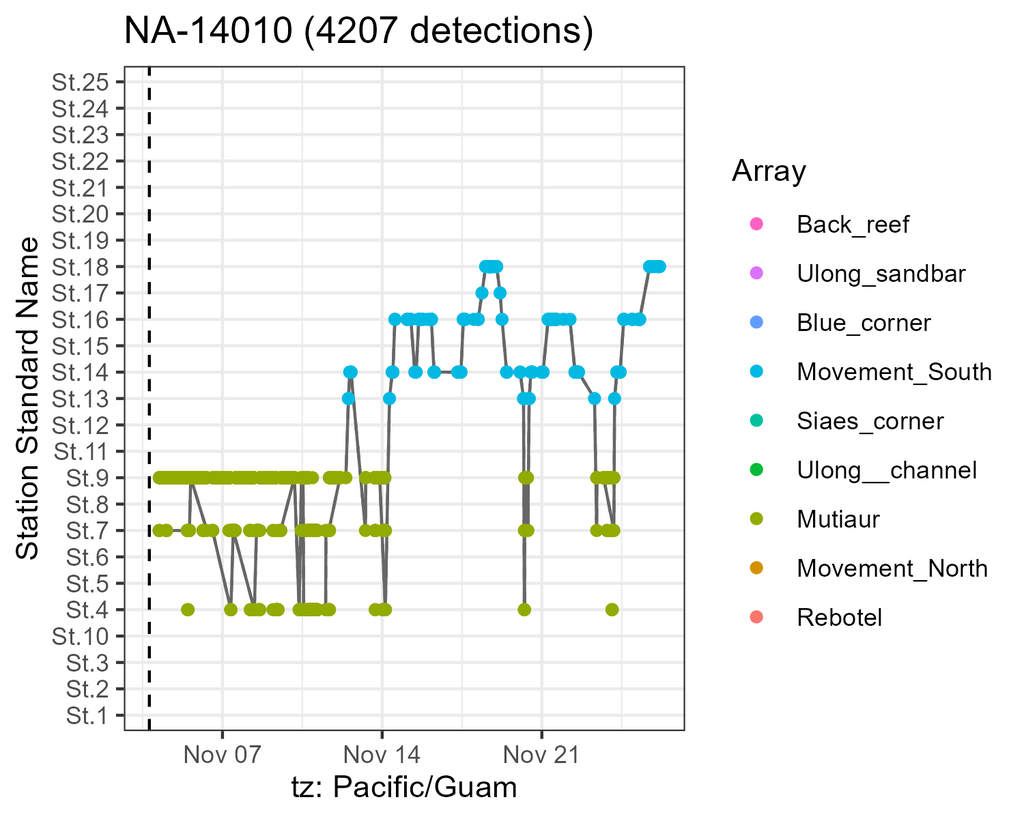

### Full log

[output not shown]

Index:

Summary Study area Stations Deployments Release sites Warnings Comments Biometrics Arrival times Individual detections Full log